# FoodFusion Q1: What drives user conversion?

Jason Pemberton

2025-03-21

## What drives user conversion?

Business insight: Identify the key factors influencing whether a user converts.  
**Approach:**

- Use Logistic Regression or Random Forest Classifier to model the relationship between the predictors *subscribing_channel*, *dietary_preference*, *meal_type*, *location*, *age_group*) and the target variable *converted*
- Evaluate feature importance to understand the weight of each factor on conversions.
- Provide actionable insights, such as targeting specific user segments for better conversion rates.

Output: A ranked list of factors that drive conversions

STEP 1: Load Libraries

```r
library(tidyverse)
library(caret)
library(randomForest)
```

STEP 2: Load Data

```r
# Load dataset
df <- read.csv("C:/Users/jason/OneDrive/SAIT/SAIT Instructor/2025-2026/WINTER 2025 - COURSE - PROJ406/Team 7/data/foodfusion.csv")

# Load dataset
df2 <- read.csv("C:/Users/jason/OneDrive/SAIT/SAIT Instructor/2025-2026/WINTER 2025 - COURSE - PROJ406/Team 7/data/foodfusion.csv")
```

STEP 3: Data Preparation

```r
# Preprocess data
df <- df %>%
  select(-user_id, -date_served, -is_retained)  # Drop unnecessary columns
df$converted <- as.factor(df$converted)  # Ensure the target is a factor

# Preprocess data
df2 <- df2 %>%
  select(-user_id, -date_served)  # Drop unnecessary columns
df2$converted <- as.factor(df2$converted)  # Ensure the target is a factor
```

STEP 4: Data Partition

```r
# Split data into training and testing sets
set.seed(123)  # For reproducibility
train_index <- createDataPartition(df$converted, p = 0.7, list = FALSE)
train_data <- df[train_index, ]
test_data <- df[-train_index, ]
```

STEP 5: Train GLM Model

```r
# Train logistic regression model
logistic_model <- glm(converted ~ ., data = train_data, family = "binomial")
```

STEP 6: Summarize Model Results

```
##
## Call:
## glm(formula = converted ~ ., family = "binomial", data = train_data)
##
## Coefficients:
##                                 Estimate Std. Error z value Pr(>|z|)
## (Intercept)                    -0.153936   0.112632  -1.367  0.17171
## subscribing_channelFacebook     0.247289   0.082893   2.983  0.00285 **
## subscribing_channelHouse Ads    0.206341   0.083222   2.479  0.01316 *
## subscribing_channelInfluencers  0.087719   0.082645   1.061  0.28851
## subscribing_channelInstagram    0.221712   0.083542   2.654  0.00796 **
## subscribing_channelPush         0.169097   0.082548   2.048  0.04051 *
## dietary_preferenceKeto          0.057010   0.074679   0.763  0.44522
## dietary_preferenceOmnivore     -0.011754   0.075854  -0.155  0.87686
## dietary_preferenceVegan         0.032598   0.075099   0.434  0.66424
## dietary_preferenceVegetarian   -0.045530   0.076189  -0.598  0.55011
## meal_typeDinner                -0.042939   0.068112  -0.630  0.52842
## meal_typeLunch                 -0.028828   0.068444  -0.421  0.67362
## meal_typeSnack                 -0.027605   0.067828  -0.407  0.68402
## locationGreenwich               0.002867   0.075082   0.038  0.96954
## locationHackney                 0.039210   0.076356   0.514  0.60760
## locationHammersmith and Fulham  0.035546   0.075259   0.472  0.63670
## locationIslington               0.046825   0.075838   0.617  0.53695
## age_group19-24 years           -0.051488   0.082926  -0.621  0.53468
## age_group25-30 years           -0.017116   0.083357  -0.205  0.83731
## age_group31-36 years            0.053144   0.083505   0.636  0.52450
## age_group37-45 years            0.030706   0.083305   0.369  0.71242
## age_group46+ years             -0.012352   0.083562  -0.148  0.88248
## ---
## Signif. codes:  0 '***' 0.001 '**' 0.01 '*' 0.05 '.' 0.1 ' ' 1
##
## (Dispersion parameter for binomial family taken to be 1)
##
##     Null deviance: 9703.9  on 6999  degrees of freedom
## Residual deviance: 9685.5  on 6978  degrees of freedom
## AIC: 9729.5
##
## Number of Fisher Scoring iterations: 3
```

STEP 7: Make Predictions on the Test data

```r
# Make predictions on the test set
test_data$predicted_prob <- predict(logistic_model, newdata = test_data, type = "response")
test_data$predicted_class <- ifelse(test_data$predicted_prob > 0.5, 1, 0)

# Ensure predicted_class and converted are factors with the same levels
test_data$predicted_class <- factor(test_data$predicted_class, levels = c(0, 1))
test_data$converted <- factor(test_data$converted, levels = c(0, 1))
```

STEP 8: Evaluate Model Performance

```
## Confusion Matrix and Statistics
##
##           Reference
## Prediction 0 1
##          0 0 0
##          1 0 0
##
##                Accuracy : NaN
##                  95% CI : (NA, NA)
##     No Information Rate : NA
##     P-Value [Acc > NIR] : NA
##
##                   Kappa : NaN
##
##  Mcnemar's Test P-Value : NA
##
##             Sensitivity :  NA
##             Specificity :  NA
##          Pos Pred Value :  NA
##          Neg Pred Value :  NA
##              Prevalence : NaN
##          Detection Rate : NaN
##    Detection Prevalence : NaN
##       Balanced Accuracy :  NA
##
##        'Positive' Class : 0
##
```

STEP 9: Feature Importance

STEP 10: Visualize Feature Importance

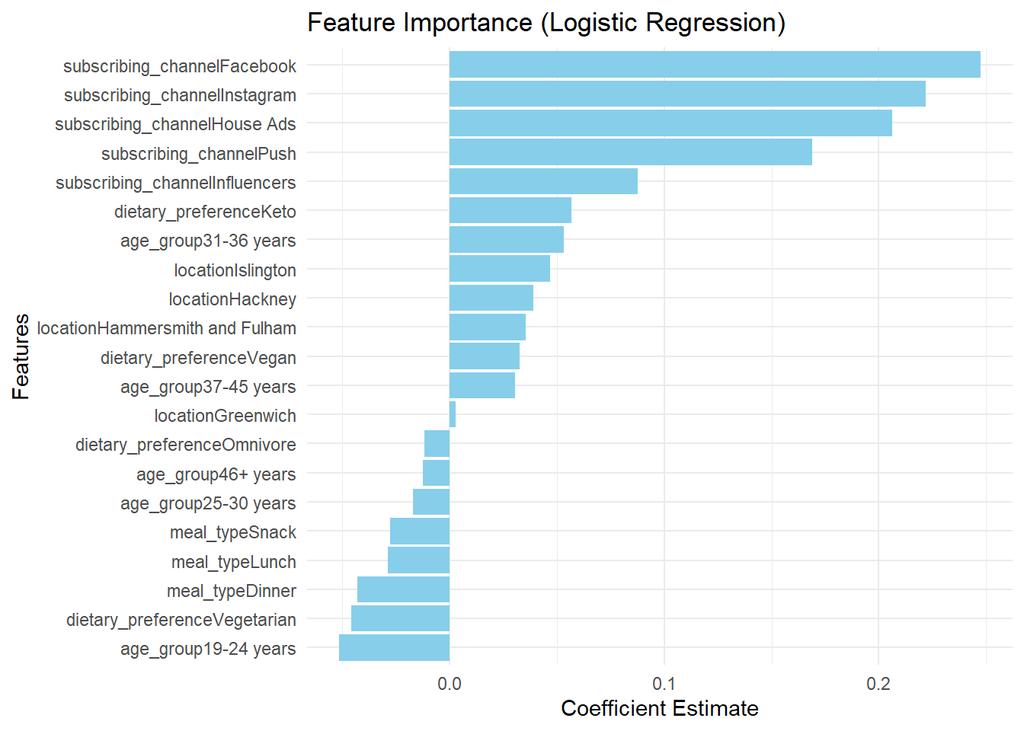

STEP 11: Top Features

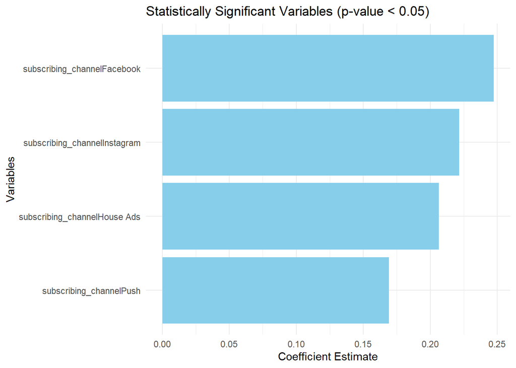

STEP 12: Conversion Rates by Subscribing Channel

```
## # A tibble: 6 × 4
##   subscribing_channel total converted percent_converted
##   <chr>               <int>     <int>             <dbl>
## 1 Instagram            1650       852              51.6
## 2 Facebook             1679       863              51.4
## 3 House Ads            1661       852              51.3
## 4 Push                 1672       836              50
## 5 Influencers          1657       804              48.5
## 6 Email                1681       813              48.4
```

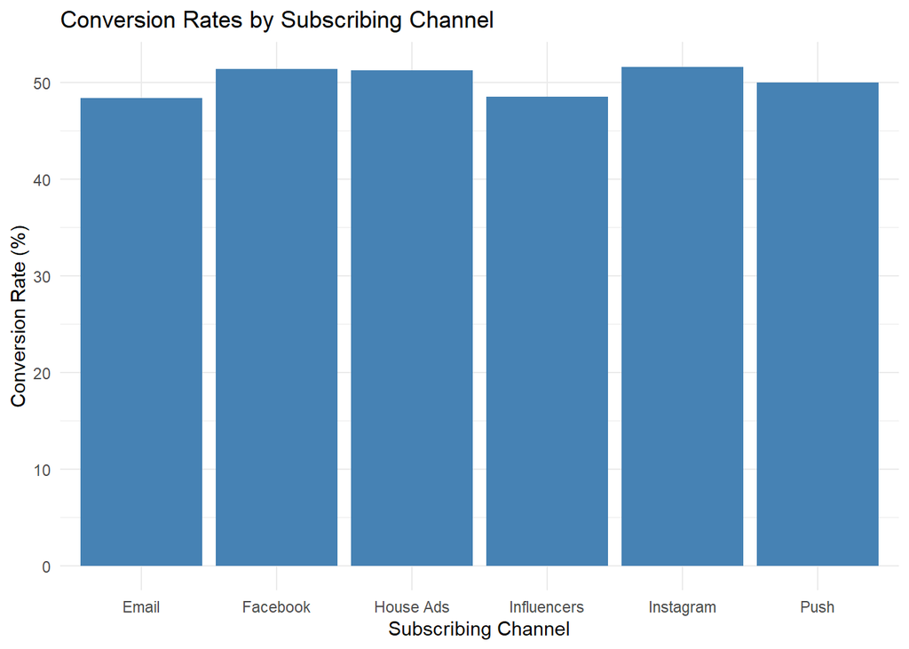

STEP 13: Random Forest Model

```
##                              0           1 MeanDecreaseAccuracy
## subscribing_channel  1.5658989 -1.35319295           0.08001855
## dietary_preference  -4.8373942 -8.08005149          -9.20384638
## meal_type           -3.9123228 -4.04507183          -5.73700647
## location             0.7770305 -5.85531058          -3.70149131
## age_group           -2.5608941 -0.09974609          -1.86323897
##                     MeanDecreaseGini
## subscribing_channel         235.3560
## dietary_preference          218.8390
## meal_type                   173.2861
## location                    221.9645
## age_group                   252.9059
```

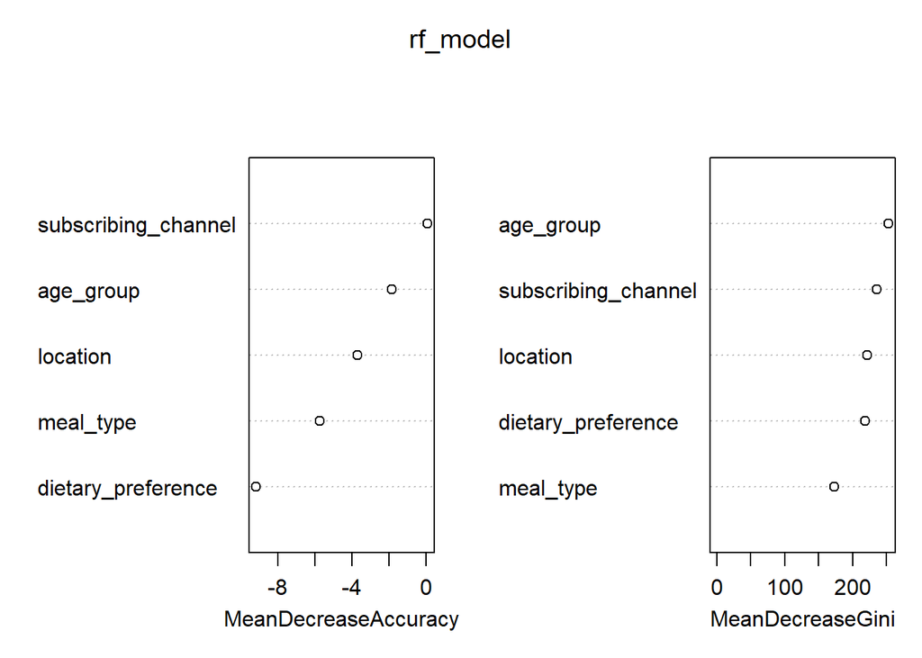

## What drives user retention?

Business insight: Identify the key factors influencing whether a user stays with FoodFusion.

**Approach:**

- Use GLM to model the relationship between the predictors *subscribing_channel*, *dietary_preference*, *meal_type*, *location*, *age_group*) and the target variable *is_retained*
- Evaluate feature importance to understand the weight of each factor on retention.
- Provide actionable insights, such as targeting specific user segments for better retention rates.

Output: A ranked list of factors that drive retention

#### Logistic Regression (GLM):

- Works well with **encoded categorical data**.
- Provides **coefficients** to explain which features (e.g., subscribing channel) are most important.
- Output: Probability of **“is_retained” = TRUE** for each customer.

```r
#df$is_retained <- as.factor(df$is_retained)  # Ensure target is categorical
glm_model <- glm(is_retained ~ ., data = df2, family = "binomial")  # Logistic regression
summary(glm_model)  # View significant predictors
```

```
##
## Call:
## glm(formula = is_retained ~ ., family = "binomial", data = df2)
##
## Coefficients:
##                                  Estimate Std. Error z value Pr(>|z|)
## (Intercept)                    -19.623524 152.133547  -0.129   0.8974
## subscribing_channelFacebook      0.109690   0.098162   1.117   0.2638
## subscribing_channelHouse Ads     0.215283   0.098516   2.185   0.0289 *
## subscribing_channelInfluencers   0.155599   0.099946   1.557   0.1195
## subscribing_channelInstagram     0.075237   0.098603   0.763   0.4454
## subscribing_channelPush          0.037771   0.099086   0.381   0.7031
## convertedTRUE                   19.544468 152.133494   0.128   0.8978
## dietary_preferenceKeto          -0.210737   0.088932  -2.370   0.0178 *
## dietary_preferenceOmnivore      -0.053003   0.090289  -0.587   0.5572
## dietary_preferenceVegan         -0.174808   0.089563  -1.952   0.0510 .
## dietary_preferenceVegetarian    -0.082979   0.090143  -0.921   0.3573
## meal_typeDinner                 -0.016725   0.079868  -0.209   0.8341
## meal_typeLunch                  -0.015970   0.080974  -0.197   0.8436
## meal_typeSnack                  -0.114865   0.080122  -1.434   0.1517
## locationGreenwich                0.110541   0.088774   1.245   0.2131
## locationHackney                 -0.057183   0.090528  -0.632   0.5276
## locationHammersmith and Fulham   0.011735   0.089636   0.131   0.8958
## locationIslington                0.071851   0.089162   0.806   0.4203
## age_group19-24 years             0.061169   0.098653   0.620   0.5352
## age_group25-30 years             0.123457   0.098146   1.258   0.2084
## age_group31-36 years             0.087398   0.097179   0.899   0.3685
## age_group37-45 years             0.135651   0.097641   1.389   0.1647
## age_group46+ years              -0.004953   0.097290  -0.051   0.9594
## ---
## Signif. codes:  0 '***' 0.001 '**' 0.01 '*' 0.05 '.' 0.1 ' ' 1
##
## (Dispersion parameter for binomial family taken to be 1)
##
##     Null deviance: 11193.7  on 9999  degrees of freedom
## Residual deviance:  6933.8  on 9977  degrees of freedom
## AIC: 6979.8
##
## Number of Fisher Scoring iterations: 18
```

**Interpretation of Significant Variables**

**Subscribing Channel (House Ads)**

- **Estimate: 0.2153, p = 0.0289** (*Significant, p < 0.05*)
- Interpretation: Users who subscribed via House Ads are significantly more likely to be retained compared to the baseline subscribing channel.

**Dietary Preference (Keto)**

- **Estimate: -0.2107, p = 0.0178** (*Significant, p < 0.05)*
- Interpretation: Keto users are significantly *less* likely to be retained compared to the baseline dietary preference.

**Dietary Preference (Vegan)**

- **Estimate: -0.1748, p = 0.0510** (*Marginally Significant, p ~ 0.05*)
- Interpretation: Vegan users might also be less likely to be retained, but it’s borderline.

#### **Recommendations for FoodFusion**

1. **Optimize House Ads** → Since it significantly increases retention, FoodFusion should invest more in this channel.
2. **Investigate Keto Dieters** → They seem less likely to be retained. Maybe they need different marketing, better meal options, or a different onboarding approach.
3. **Ignore Insignificant Variables for Now** → Since age, location, and other meal types don’t have a strong effect, there’s no need to focus marketing efforts there.